# One-line Monte Carlo simulation

Ian Hussey

17 February, 2026

# Math

## 1. Sample Means

For each group, the sample mean is calculated as:

$$\bar{x} = \frac{1}{n} \sum_{i=1}^{n} x_i$$

## 2. Sample Variance and Standard Deviation

Sample variance:

$$s^2 = \frac{1}{n - 1} \sum_{i=1}^{n} (x_i - \bar{x})^2$$

Sample standard deviation:

$$s = \sqrt{s^2}$$

Let $s_1, s_2$ and $n_1, n_2$ be the standard deviations and sample sizes of group 1 and group 2.

## 3. Standard Error of the Difference Between Means

Assuming independent samples:

$$SE = \sqrt{ \frac{s_1^2}{n_1} + \frac{s_2^2}{n_2} }$$

## 4. Test Statistic (t)

The t-statistic is calculated as:

$$t = \frac{ \bar{x}_1 - \bar{x}_2 }{SE}$$

This t-statistic represents the standardized difference between the sample means under the assumption that the null hypothesis $H_0: \mu_1 = \mu_2$ is true.

## 5. Degrees of Freedom (Welch’s Approximation)

Because the two samples may have different variances, we use the Welch-Satterthwaite approximation for degrees of freedom:

$$df = \frac{ \left( \frac{s_1^2}{n_1} + \frac{s_2^2}{n_2} \right)^2 }{
\frac{ \left( \frac{s_1^2}{n_1} \right)^2 }{n_1 - 1} +
\frac{ \left( \frac{s_2^2}{n_2} \right)^2 }{n_2 - 1}
}$$

This value of $df$ determines which **t-distribution** we reference when calculating the p-value.

## 6. p-Value

Given the calculated t-statistic and degrees of freedom, the p-value is computed as the probability of observing a t-value at least as extreme as the one obtained:

- For a two-sided test:

$$p = 2 \cdot P(T_{df} > |t|)$$

Where $T_{df}$ denotes a t-distribution with the calculated degrees of freedom.

## The t-Distribution

The **Student’s t-distribution** arises when standardizing the difference between a sample mean and a population mean, using the **sample standard deviation** instead of the population standard deviation. If $X_1, \dots, X_n \sim \mathcal{N}(\mu, \sigma^2)$, then:

$$t = \frac{\bar{X} - \mu}{S / \sqrt{n}} \sim t_{n - 1}$$

where:

- $\bar{X}$ is the sample mean,
- $S$ is the sample standard deviation,
- $n$ is the sample size,
- and the degrees of freedom are $df = n - 1$.

The t-distribution is derived from the ratio of a standard normal variable and the square root of a scaled chi-squared variable:

$$t = \frac{Z}{\sqrt{V / \nu}} \quad \text{where } Z \sim
\mathcal{N}(0,1),\; V \sim \chi^2_{\nu},\; Z \perp V$$

Thus, the t-distribution with $\nu$ degrees of freedom is defined by:

$$t \sim \frac{Z}{\sqrt{V/\nu}} \sim t_{\nu}$$

## Probability Density Function (PDF)

The probability density function of the t-distribution with $\nu$ degrees of freedom is:

$$f(t) = \frac{ \Gamma\left(\frac{\nu + 1}{2}\right) }
{ \sqrt{\nu \pi} \, \Gamma\left(\frac{\nu}{2}\right) }
\left(1 + \frac{t^2}{\nu} \right)^{ -\frac{\nu + 1}{2} }$$

Where $\Gamma(\cdot)$ is the gamma function, a generalization of the factorial:

$$\Gamma(n) = (n - 1)!$$

This function defines the shape of the t-distribution used to determine p-values for a given t-statistic.

# combined

$$\bar{x} = \frac{1}{n} \sum_{i=1}^{n} x_i$$

$$s^2 = \frac{1}{n - 1} \sum_{i=1}^{n} (x_i - \bar{x})^2$$

$$SE = \sqrt{ \frac{s_1^2}{n_1} + \frac{s_2^2}{n_2} }$$

$$t = \frac{ \bar{x}_1 - \bar{x}_2 }{SE}$$

$$df = \frac{ \left( \frac{s_1^2}{n_1} + \frac{s_2^2}{n_2} \right)^2 }{
\frac{ \left( \frac{s_1^2}{n_1} \right)^2 }{n_1 - 1} +
\frac{ \left( \frac{s_2^2}{n_2} \right)^2 }{n_2 - 1}
}$$

$$t = \frac{\bar{X} - \mu}{S / \sqrt{n}} \sim t_{n - 1}$$
$$f(t) = \frac{ \Gamma\left(\frac{\nu + 1}{2}\right) }
{ \sqrt{\nu \pi} \, \Gamma\left(\frac{\nu}{2}\right) }
\left(1 + \frac{t^2}{\nu} \right)^{ -\frac{\nu + 1}{2} }$$

$$\Gamma(n) = (n - 1)!$$

$$p = 2 \cdot P(T_{df} > |t|)$$

# Plots

```r
# params
mu_control <- 19
mu_intervention <- 15
target_var <- 8^2 # 64
n_per_group <- 25
```

## Visualise sample

DGP neg binomial, analysis assumes gaussian

```r
library(ggplot2)
library(ggdist)  # for geom_dots
library(janitor)
library(roundwork)
library(dplyr)
library(tidyverse)
library(ggdist)

for(study in 1:5){
  set.seed(study+10)

  # Calculate dispersion (size) to match SD = 8
  # Formula: size = mu^2 / (var - mu)
  theta_control <- mu_control^2 / (target_var - mu_control)
  theta_intervention <- mu_intervention^2 / (target_var - mu_intervention)

  df <- data.frame(
    Group = rep(c("Control", "Intervention"), each = n_per_group),
    Score = c(
      rnbinom(n_per_group, mu = mu_control, size = theta_control),
      rnbinom(n_per_group, mu = mu_intervention, size = theta_intervention)
    )
  )

  mean_diff <- mean(df$Score[df$Group == "Intervention"]) - mean(df$Score[df$Group == "Control"])

# Use it in your subtitle

  # Dot-only raincloud-style plot
  ggplot(df, aes(x = Group, y = Score, color = Group, fill = Group)) +
    ggdist::geom_dots(
      side = "right",
      scale = 0.8,
      dotsize = 0.75,
      binwidth = 1
    ) +
    scale_color_manual(values = c("Control" = "steelblue", "Intervention" = "tomato")) +
    scale_fill_manual(values = c("Control" = "steelblue", "Intervention" = "tomato")) +
    scale_y_continuous(
      name = "Depression score",
      breaks = scales::breaks_pretty(n = 10),
      limits = c(0, 45)
    ) +
    coord_flip() +
    theme_linedraw() +
    labs(
      title = paste0("Study ", study),
      # subtitle = paste0("Mean intervention = ", round_up(mean(df$Score[df$Group == "Intervention"]), 1),
      #                   ", Mean control = ", round_up(mean(df$Score[df$Group == "Control"], 1)),
      #                   ", Pooled SD = ", round_up(mean(c(sd(df$Score[df$Group == "Intervention"]),
      #                                                     sd(df$Score[df$Group == "Intervention"]))), 1)),
      subtitle = paste0("Difference in means = ", roundwork::round_up(mean_diff, 1)),
      color = "Group",
      x = ""
    ) +
    theme(legend.position = "none")

  ggsave(paste0("sample_effect_study_", study, ".png"),
         width = 7,
         height = 3)
}
```

## Visualise population gaussian

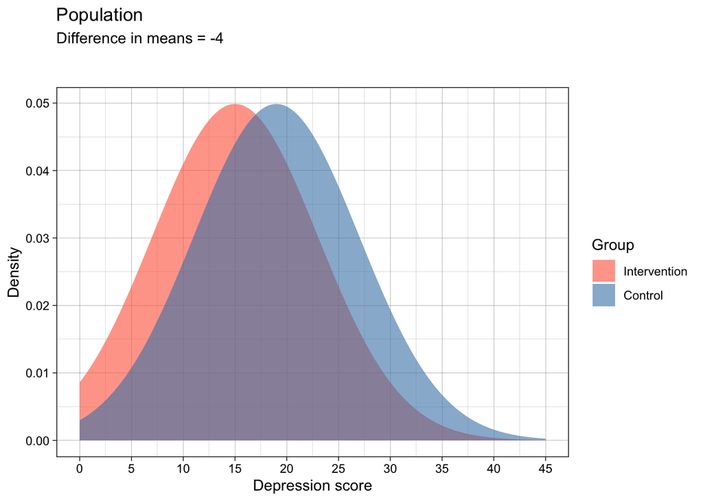

```r
# Generate a sequence of x values for a smooth curve
x_vals <- seq(0, 45, length.out = 1000)

plot_data_norm <- tibble(x = x_vals) %>%
  mutate(
    Control = dnorm(x, mean = mu_control, sd = sqrt(target_var)),
    Intervention = dnorm(x, mean = mu_intervention, sd = sqrt(target_var))
  ) %>%
  pivot_longer(cols = c(Control, Intervention),
               names_to = "Group",
               values_to = "Density") |>
  mutate(Group = fct_relevel(Group, "Intervention", "Control"))

ggplot(plot_data_norm, aes(x = x, y = Density, fill = Group)) +
  geom_area(alpha = 0.6, position = "identity") +
  scale_fill_manual(values = c("Control" = "steelblue", "Intervention" = "tomato")) +
  labs(title = "Population",
       #subtitle = paste0("Mean intervention = ", mu_control, ", Mean control = ", mu_intervention, ", Pooled SD = ", sqrt(target_var)),
       subtitle = paste0(
      "Difference in means = ", roundwork::round_up(mu_intervention - mu_control, 1), "\n\n"
    ),
       x = "Depression score",
       y = "Density",
       fill = "Group") +
  scale_y_continuous(breaks = scales::breaks_pretty(n = 5)) +
  scale_x_continuous(breaks = scales::breaks_pretty(n = 9),
                     limits = c(0, 45)) +
  theme_linedraw()
```

```r
ggsave("population_effect_normal.png",
       width = 7,
       height = 5)
```

## Visualise population neg binomial

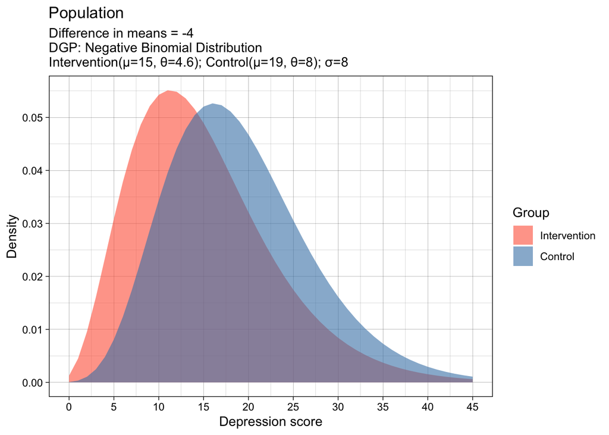

```r
# Calculate dispersion (size) for each group to keep SD constant at 8
theta_control <- round(mu_control^2 / (target_var - mu_control), 1)
theta_intervention  <- round(mu_intervention^2 / (target_var - mu_intervention), 1)

plot_data <- tibble(x = 0:50) %>%
  mutate(
    Control = dnbinom(x, mu = mu_control, size = theta_control),
    Intervention = dnbinom(x, mu = mu_intervention, size = theta_intervention)
  ) %>%
  pivot_longer(cols = c(Control, Intervention),
               names_to = "Group",
               values_to = "Probability") |>
  mutate(Group = fct_relevel(Group, "Intervention", "Control"))

ggplot(plot_data, aes(x = x, y = Probability, fill = Group)) +
  geom_area(alpha = 0.6, position = "identity") +
  scale_fill_manual(values = c("Control" = "steelblue", "Intervention" = "tomato")) +
  labs(
    title = "Population",
    subtitle = paste0(
      "Difference in means = ", roundwork::round_up(mu_intervention - mu_control, 1), "\n",
      "DGP: Negative Binomial Distribution\nIntervention(μ=", mu_intervention, ", θ=", theta_intervention,
      "); Control(μ=", mu_control, ", θ=", theta_control,
      "); σ=", sqrt(target_var)
    ),
    y = "Density",
    fill = "Group"
  ) +
  scale_y_continuous(breaks = scales::breaks_pretty(n = 5)) +
  scale_x_continuous(
    name = "Depression score",
    breaks = scales::breaks_pretty(n = 9),
    limits = c(0, 45)
  ) +
  theme_linedraw()
```

```r
ggsave("population_effect_negbinomial.png",
       width = 7,
       height = 5)
```

# other

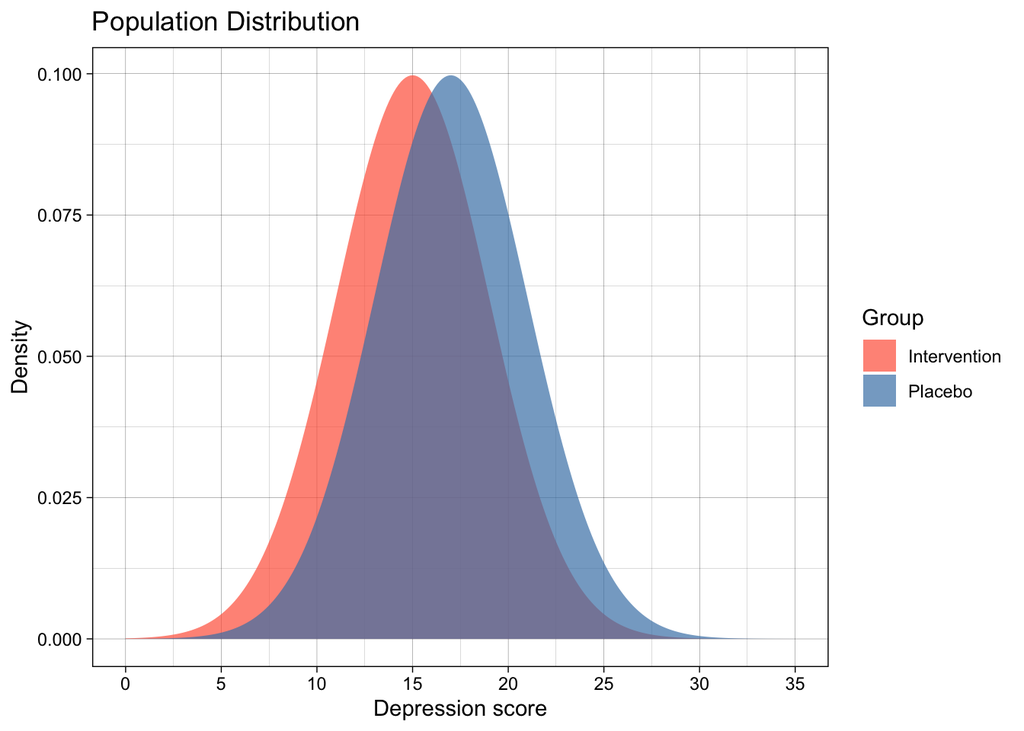

```r
set.seed(42)

x_vals <- seq(0, 63, length.out = 500)

df_plot <- bind_rows(
  data.frame(
    x = x_vals,
    density = dnorm(x_vals, mean = 17, sd = 4),
    Group = "Placebo"
  ),
  data.frame(
    x = x_vals,
    density = dnorm(x_vals, mean = 15, sd = 4),
    Group = "Intervention"
  )
)

# Plot with shaded area under the curve
ggplot(df_plot, aes(x = x, y = density, fill = Group)) +
  geom_area(alpha = 0.7, position = "identity") +
  scale_fill_manual(values = c("Placebo" = "steelblue", "Intervention" = "tomato")) +
  labs(title = "Population Distribution", x = "x", y = "Density") +
  theme_linedraw() +
  scale_x_continuous(name = "Depression score",
                     breaks = scales::breaks_pretty(n = 8),
                     limits = c(0, 35))
```

```r
# ggsave("pop.png",
#        width = 7,
#        height = 5)
```

# PRNG

```r
library(janitor)


runif(n = 3, min = 1, max = 10) |> round_half_up(digits = 0)
```

```
## [1] 9 9 4
```

```r
runif(n = 3, min = 1, max = 10) |> round_half_up(digits = 0)
```

```
## [1] 8 7 6
```

```r
runif(n = 3, min = 1, max = 10) |> round_half_up(digits = 0)
```

```
## [1] 8 2 7
```

```r
library(janitor)

set.seed(42)
runif(n = 3, min = 1, max = 10) |> round_half_up(digits = 0)
```

```
## [1] 9 9 4
```

```r
set.seed(42)
runif(n = 3, min = 1, max = 10) |> round_half_up(digits = 0)
```

```
## [1] 9 9 4
```

```r
set.seed(42)
runif(n = 3, min = 1, max = 10) |> round_half_up(digits = 0)
```

```
## [1] 9 9 4
```

# multivariate data

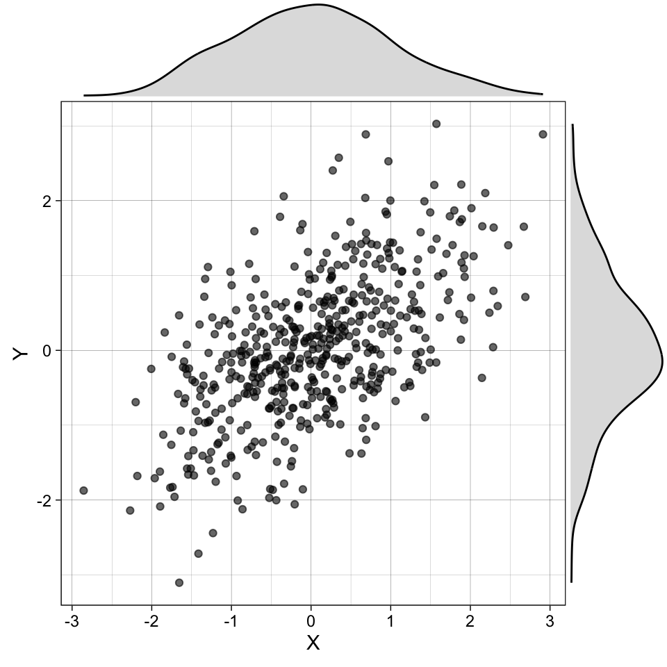

```r
# Load required packages
library(ggplot2)

library(ggExtra)

# Generate multivariate normal data
# For example, 500 observations of two variables with correlation = 0.6
set.seed(123)  # for reproducibility

library(faux)
dat <- rnorm_multi(n = 500,
                   vars = 2,
                   varnames = c("X", "Y"),
                   mu = 0,
                   sd = 1,
                   r = 0.6)

p <- ggplot(dat, aes(x = X, y = Y)) +
  geom_point(alpha = 0.6) +
  theme_linedraw()

ggMarginal(p, type = "density", fill = "gray", alpha = 0.5)
```

```r
# ggsave("scatter.png",
#        width = 5,
#        height = 5)
```